# CS 422 Section 01

Avinash Vellineni - A20406657

## Assignment 3

### Problem 2.1

### Question 2.1-A-i

I didn’t omit any attributes from the dataset. All of the attributes are considered for clustering.

### Question 2.1-A-ii

The dataset dosen’t need to be standardized. All the observation values lie in the range[0-8].

### Question 2.1-A-iii

The data is cleaned to remove multiple spaces and comma character is made as the delimiter.The cleaned dataset is uploaded as part of the assignmnet submission.

### Question 2.1-B-i

```r
rm(list=ls())
setwd("E:/IIT CHICAGO STUDIES/IIT Chicago semester 2/Data Mining/Assignments/Assignmnet3")
library(factoextra)
library(cluster)
library(fpc)
library(ggplot2)
```

```r
mammals <- read.csv("file19.csv",sep=",", header=T,row.names = 1)
head(mammals)
```

|  | I | i | C | c | P | p | M | m |
| --- | --- | --- | --- | --- | --- | --- | --- | --- |
| Opossum | 5 | 4 | 1 | 1 | 3 | 3 | 4 | 4 |
| Hairy tail mole | 3 | 3 | 1 | 1 | 4 | 4 | 3 | 3 |
| Common mole | 3 | 2 | 1 | 0 | 3 | 3 | 3 | 3 |
| Star nose mole | 3 | 3 | 1 | 1 | 4 | 4 | 3 | 3 |
| Brown bat | 2 | 3 | 1 | 1 | 3 | 3 | 3 | 3 |
| Silver hair bat | 2 | 3 | 1 | 1 | 2 | 3 | 3 | 3 |

```r
summary(mammals)
```

```
       I             i              C               c               P              p
 Min.   :0.0   Min.   :0.00   Min.   :0.000   Min.   :0.000   Min.   :0.00   Min.   :0.00
 1st Qu.:1.0   1st Qu.:1.00   1st Qu.:0.000   1st Qu.:0.000   1st Qu.:2.00   1st Qu.:1.00
 Median :2.0   Median :3.00   Median :1.000   Median :1.000   Median :3.00   Median :3.00
 Mean   :1.8   Mean   :2.38   Mean   :0.591   Mean   :0.545   Mean   :2.56   Mean   :2.42
 3rd Qu.:3.0   3rd Qu.:3.00   3rd Qu.:1.000   3rd Qu.:1.000   3rd Qu.:3.00   3rd Qu.:3.00
 Max.   :5.0   Max.   :4.00   Max.   :1.000   Max.   :1.000   Max.   :4.00   Max.   :4.00
       M              m
 Min.   :0.00   Min.   :0.00
 1st Qu.:1.00   1st Qu.:2.00
 Median :3.00   Median :3.00
 Mean   :2.45   Mean   :2.64
 3rd Qu.:3.00   3rd Qu.:3.00
 Max.   :8.00   Max.   :8.00
```

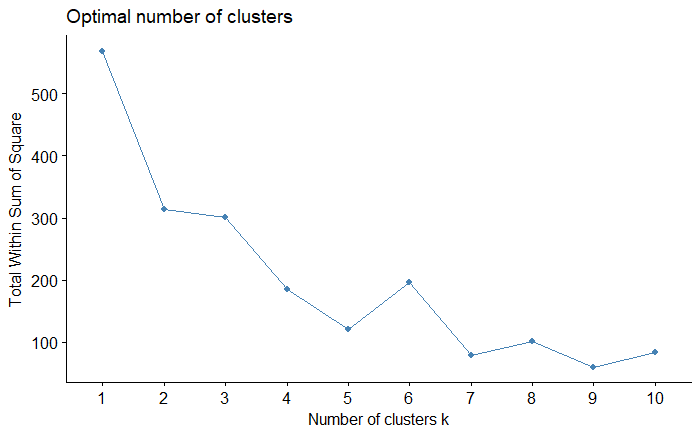

```r
fviz_nbclust(mammals, kmeans, method="wss")
```

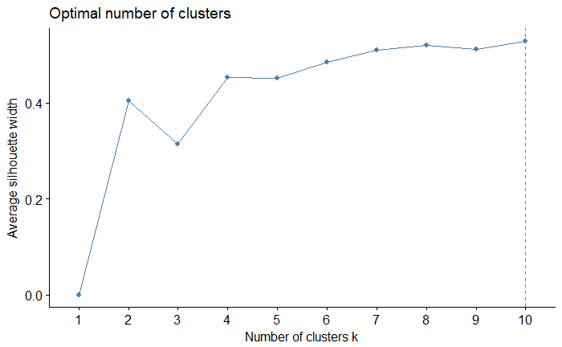

```r
fviz_nbclust(mammals, kmeans, method="silhouette")
```

On determining the WSS graph and silhouette graph,I am selecting the number of clusters to be 7 as there is not much decrease in total within sum of squares after k=7 (No of clusters).

### Question 2.1-B-ii

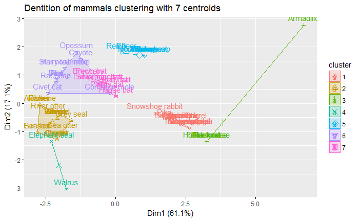

```r
mammals_km_7 <- kmeans(mammals,centers=7)
fviz_cluster(mammals_km_7, data=mammals, main="Dentition of mammals clustering with 7 centroids")
```

### Question 2.1-B-iii

```r
names(mammals_km_7)
```

```
[1] "cluster"      "centers"      "totss"        "withinss"     "tot.withinss" "betweenss"
[7] "size"         "iter"         "ifault"
```

```r
cat("Number of observations in each cluster are: ",mammals_km_7$size)
```

```
Number of observations in each cluster are:  14 17 6 2 9 10 8
```

### Question 2.1-B-iv

```r
cat("Total SSE of the cluster is: ",mammals_km_7$totss)
```

```
Total SSE of the cluster is:  568.3
```

### Question 2.1-B-v

```r
cat("SSE of each cluster are: ",mammals_km_7$withinss)
```

```
SSE of each cluster are:  8.6429 20.706 43.333 3 1.5556 21.1 6.375
```

### Question 2.1-B-vi

```r
which(mammals_km_7$cluster == 1)
```

```
           Pika Snowshoe rabbit          Beaver          Marmot       Groundhog     Prairie Dog
             13              14              15              16              17              18
Ground Squirrel        Chipmunk   Gray squirrel    Fox squirrel   Pocket gopher    Kangaroo rat
             19              20              21              22              23              24
      Porcupine      Guinea pig
             30              31
```

```r
which(mammals_km_7$cluster == 2)
```

```
     Marten      Fisher      Weasel        Mink      Ferrer   Wolverine      Badger       Skunk
         38          39          40          41          42          43          44          45
River otter   Sea otter      Jaguar      Ocelot      Cougar        Lynx    Fur seal    Sea lion
         46          47          48          49          50          51          52          53
  Grey seal
         55
```

```r
which(mammals_km_7$cluster == 3)
```

```
  Armadillo    Pack rat Field mouse     Muskrat   Black rat House mouse
         12          25          26          27          28          29
```

```r
which(mammals_km_7$cluster == 4)
```

```
       Walrus Elephant seal
           54            56
```

```r
which(mammals_km_7$cluster == 5)
```

```
           Elk           Deer          Moose       Reindeer       Antelope          Bison
            58             59             60             61             62             63
 Mountain goat        Musk ox Mountain sheep
            64             65             66
```

```r
which(mammals_km_7$cluster == 6)
```

```
        Opossum Hairy tail mole     Common mole  Star nose mole          Coyote            Wolf
              1               2               3               4              32              33
            Fox            Bear       Civet cat         Raccoon
             34              35              36              37
```

```r
which(mammals_km_7$cluster == 7)
```

```
      Brown bat Silver hair bat       Pigmy bat       House bat         Red bat       Hoary bat
              5               6               7               8               9              10
  Lump nose bat         Peccary
             11              57
```

Cluster 1 — Mammals in cluster 1 have atleast 1 top incisors , exactly 1 bottom incisors, zero top canines, zero bottom canines, atleast 1 top premolars & bottom premolars and exactly 3 top molars & bottom molars.

Cluster 2 — Mammals in cluster 2 have exactly 3 top incisors, 3 or 2 bottom incisors, exactly 1 top canines & bottom canines, exactly 1 top molars and 1 or 2 bottom molars.

Cluster 3 — Mammals in cluster 3 have exactly zero top craines,bottom craines,top premolars and bottom premolars.

Cluster 4 — Mammals in cluster 4 have exactly 1 top canines and bottom canines with 1 or 2 bottom incisors which is unique compared to other mammals.

Cluster 5 — Mammals in cluster 5 have exactly zero top incisors and 4 bottom incisors.

Cluster 6 — Mammals in cluster 6 have 1 or 3 or 5 top incisors, 2 or 3 or 4 bottom incisors , exactly 1 top craines, 0 or 1 bottom craines, 3 or 4 top and bottom premolars and 2 or 3 or 4 top and bottom molars.

Cluster 7 — Mammals in cluster 7 have exactly 1 top and bottom canines ,exactly 3 top & bottom molars and leass than 4 top & bottom premolars.

Since the mammals are divided uniquely according to their tooth pattern(top incisors,bottom incisors,top canines,bottom canines,top premolars,bottom premolars,top molars,and bottom molars) among the clusters as stated above, the clustering of the mammals into 7 clusters makes sense.

### Problem 2.2

### Question 2.2-A

```r
Languages <- read.csv("file46.txt",comment.char = "#",sep=",",header=T,row.names=1)
head(Languages)
```

|  | FI | SW | DA | NO | EN | GE | DU | FL | FR | IT | SP | PO |
| --- | --- | --- | --- | --- | --- | --- | --- | --- | --- | --- | --- | --- |
| West Germany | 0 | 0 | 0 | 0 | 21 | 100 | 2 | 1 | 10 | 2 | 1 | 0 |
| Italy | 0 | 0 | 0 | 0 | 5 | 3 | 0 | 0 | 11 | 100 | 1 | 0 |
| France | 0 | 2 | 3 | 0 | 10 | 7 | 1 | 1 | 100 | 12 | 7 | 1 |
| Netherlands | 0 | 0 | 0 | 0 | 41 | 47 | 100 | 100 | 16 | 2 | 2 | 0 |
| Belgium | 0 | 0 | 0 | 0 | 14 | 15 | 0 | 59 | 44 | 2 | 1 | 0 |
| Luxemburg | 0 | 0 | 0 | 0 | 31 | 100 | 4 | 1 | 92 | 10 | 0 | 0 |

```r
summary(Languages)
```

```
       FI               SW              DA               NO               EN
 Min.   :  0.00   Min.   :  0.0   Min.   :  0.00   Min.   :  0.00   Min.   :  5.0
 1st Qu.:  0.00   1st Qu.:  0.0   1st Qu.:  0.00   1st Qu.:  0.00   1st Qu.: 11.5
 Median :  0.00   Median :  0.0   Median :  0.00   Median :  0.00   Median : 21.0
 Mean   :  6.56   Mean   : 10.8   Mean   :  8.25   Mean   :  8.19   Mean   : 31.4
 3rd Qu.:  0.00   3rd Qu.:  7.0   3rd Qu.:  0.75   3rd Qu.:  0.00   3rd Qu.: 38.8
 Max.   :100.00   Max.   :100.0   Max.   :100.00   Max.   :100.00   Max.   :100.0
       GE              DU               FL              FR              IT
 Min.   :  0.0   Min.   :  0.00   Min.   :  0.0   Min.   :  2.0   Min.   :  0.00
 1st Qu.:  6.0   1st Qu.:  0.00   1st Qu.:  0.0   1st Qu.:  5.5   1st Qu.:  1.00
 Median : 17.0   Median :  0.00   Median :  0.5   Median : 10.5   Median :  2.00
 Mean   : 34.7   Mean   :  6.88   Mean   : 10.4   Mean   : 25.1   Mean   : 10.31
 3rd Qu.: 56.0   3rd Qu.:  1.00   3rd Qu.:  1.0   3rd Qu.: 23.0   3rd Qu.:  4.75
 Max.   :100.0   Max.   :100.00   Max.   :100.0   Max.   :100.0   Max.   :100.00
       SP               PO
 Min.   :  0.00   Min.   :  0.00
 1st Qu.:  0.75   1st Qu.:  0.00
 Median :  1.00   Median :  0.00
 Mean   :  7.62   Mean   :  6.44
 3rd Qu.:  2.00   3rd Qu.:  0.25
 Max.   :100.00   Max.   :100.00
```

```r
H_cluster_single <- eclust(Languages,FUNcluster="hclust",hc_method="single")
```

```
Clustering k = 1,2,..., K.max (= 10): .. done
Bootstrapping, b = 1,2,..., B (= 100)  [one "." per sample]:
.................................................. 50
.................................................. 100
```

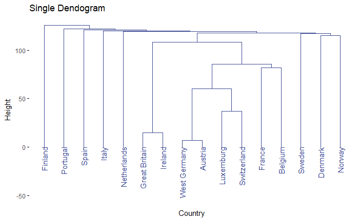

```r
fviz_dend(H_cluster_single,main="Single Dendogram",show_labels = TRUE,palette ="aaas",cex=0.8,labels_track_height=50,xlab = "Country")
```

```r
H_cluster_complete <- eclust(Languages,FUNcluster="hclust",hc_method="complete")
```

```
Clustering k = 1,2,..., K.max (= 10): .. done
Bootstrapping, b = 1,2,..., B (= 100)  [one "." per sample]:
.................................................. 50
.................................................. 100
```

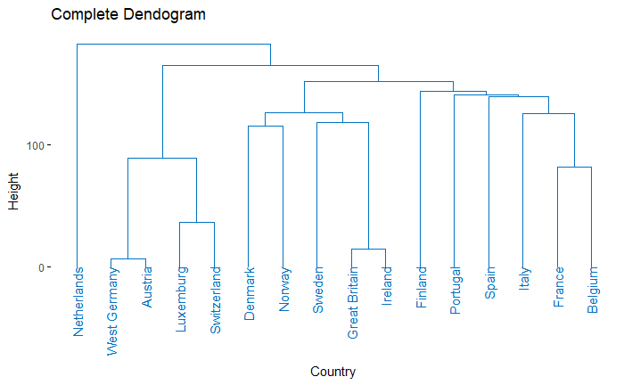

```r
fviz_dend(H_cluster_complete,main="Complete Dendogram",show_labels = TRUE,xlab = "Country",palette ="jco",cex=0.8,labels_track_height=60)
```

```r
H_cluster_average <- eclust(Languages,FUNcluster="hclust",hc_method="average")
```

```
Clustering k = 1,2,..., K.max (= 10): .. done
Bootstrapping, b = 1,2,..., B (= 100)  [one "." per sample]:
.................................................. 50
.................................................. 100
```

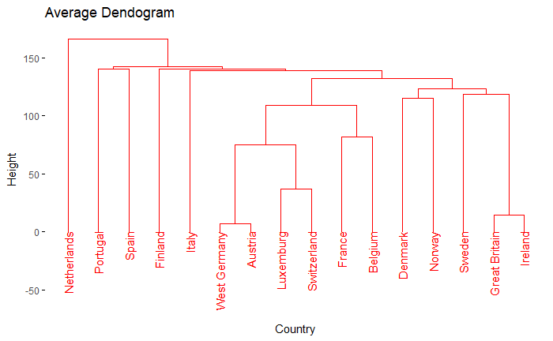

```r
fviz_dend(H_cluster_average,main="Average Dendogram",show_labels = TRUE,xlab = "Country",palette ="ucscgb",cex=0.8,labels_track_height=60)
```

### Question 2.2-B

#### Single Linkage:

{Denmark, Norway} , {France, Belgium} , {Luxemburg, Switzerland} , {West Germany, Austria} , {Great Britain, Ireland}

#### Compete Linkage:

{France, Belgium} , {Great Britain, Ireland} , {Denmark, Norway} , {Luxemburg, Switzeland} , {West Germany, Austria}

#### Average Linkage:

{Great Britain, Ireland} , {Denmark, Norway} , {Belgium, France} , {Luemburg, Switzerland} , {West Germany, Austria} , {Portugal, Spain}

### Question 2.2-C

From raw data we can observe that Italy and france share common similarity (i.e) most of the people in Italy speaks italian and few speak french which is similar to country France where most of the people speak french and few speak Italian and that is visible from complete cluster linkage.So complete cluster is best cluster for italy based on my interpretation of results.

### Question 2.2-D

Average Linkage method exhibits the most two-singleton clusters(6).

### Question 2.2-E

```r
H_average_125 <- cutree(H_cluster_average,h=125)
table(H_average_125)
```

```
H_average_125
1 2 3 4 5 6 7
6 1 1 5 1 1 1
```

```r
names(H_average_125)
```

```
 [1] "West Germany"  "Italy"         "France"        "Netherlands"   "Belgium"
 [6] "Luxemburg"     "Great Britain" "Portugal"      "Austria"       "Switzerland"
[11] "Sweden"        "Denmark"       "Norway"        "Finland"       "Spain"
[16] "Ireland"
```

There are 7 clusters if the split is made at a height 125.

### Question 2.2-F

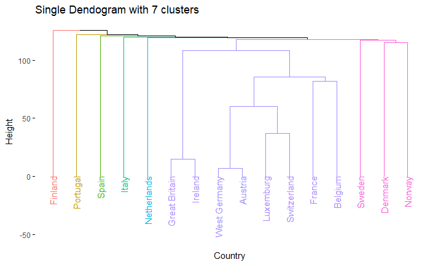

```r
H_cluster_single_re <- eclust(Languages,k=7,FUNcluster="hclust",hc_method="single")
fviz_dend(H_cluster_single_re,main="Single Dendogram with 7 clusters",show_labels = TRUE,xlab = "Country",cex=0.8,labels_track_height=50)
```

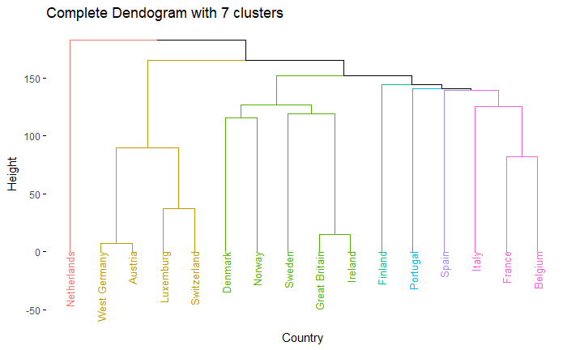

```r
H_cluster_complete_re <- eclust(Languages,k=7,FUNcluster="hclust",hc_method="complete")
fviz_dend(H_cluster_complete_re,main="Complete Dendogram with 7 clusters",show_labels = TRUE,xlab = "Country",cex=0.7,labels_track_height=50)
```

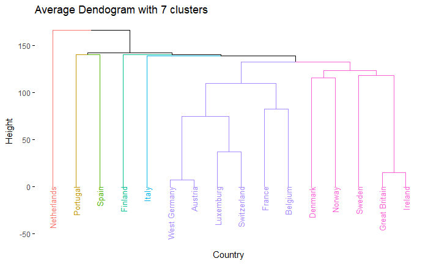

```r
H_cluster_average_re <- eclust(Languages,k=7,FUNcluster="hclust",hc_method="average")
fviz_dend(H_cluster_average_re,main="Average Dendogram with 7 clusters",show_labels = TRUE,xlab = "Country",cex=0.7,labels_track_height=50)
```

### Question 2.2-G

```r
options(digits=5)
stats_cluster_single <- cluster.stats(dist(Languages),H_cluster_single_re$cluster)
names(stats_cluster_single)
```

```
 [1] "n"                  "cluster.number"     "cluster.size"       "min.cluster.size"
 [5] "noisen"             "diameter"           "average.distance"   "median.distance"
 [9] "separation"         "average.toother"    "separation.matrix"  "ave.between.matrix"
[13] "average.between"    "average.within"     "n.between"          "n.within"
[17] "max.diameter"       "min.separation"     "within.cluster.ss"  "clus.avg.silwidths"
[21] "avg.silwidth"       "g2"                 "g3"                 "pearsongamma"
[25] "dunn"               "dunn2"              "entropy"            "wb.ratio"
[29] "ch"                 "cwidegap"           "widestgap"          "sindex"
[33] "corrected.rand"     "vi"
```

```r
cat("Dunn index for Single Linkage with 7 clusters is :",stats_cluster_single$dunn)
```

```
Dunn index for Single Linkage with 7 clusters is : 0.7813
```

```r
cat("Average Silhouette width for Single Linkage with 7 clusters is :",stats_cluster_single$avg.silwidth)
```

```
Average Silhouette width for Single Linkage with 7 clusters is : 0.12151
```

```r
stats_cluster_complete <- cluster.stats(dist(Languages),H_cluster_complete_re$cluster)
cat("Dunn index for Complete Linkage with 7 clusters is :",stats_cluster_complete$dunn)
```

```
Dunn index for Complete Linkage with 7 clusters is : 0.67688
```

```r
cat("Average Silhouette width for Complete Linkage with 7 clusters is :",stats_cluster_complete$avg.silwidth)
```

```
Average Silhouette width for Complete Linkage with 7 clusters is : 0.19223
```

```r
stats_cluster_average <- cluster.stats(dist(Languages),H_cluster_average_re$cluster)
cat("Dunn index for Average Linkage with 7 clusters is :",stats_cluster_average$dunn)
```

```
Dunn index for Average Linkage with 7 clusters is : 0.80735
```

```r
cat("Average Silhouette width for Average Linkage with 7 clusters is :",stats_cluster_average$avg.silwidth)
```

```
Average Silhouette width for Average Linkage with 7 clusters is : 0.16982
```

### Question 2.2-H

According to above dunn values Average cluster is the best cluster as it has the highest dunn value of 0.80735.

### Question 2.2-I

According to above Silhouette width values Complete Cluster is the best cluster as it has the highest Silhouette width value of 0.19223.

### Problem 2.3

### Principal Component Analysis

### Question 2.3-A-i

```r
library(tidyverse)
HTRU_2data <- read.csv("HTRU_2-small.csv",header = TRUE,sep=",")
head(HTRU_2data)
```

|  | mean | std.dev | kurtosis | skewness | mean.dm.snr | std.dev.dm.snr | kurtosis.dm.snr | skewness.dm.snr | class |
| --- | --- | --- | --- | --- | --- | --- | --- | --- | --- |
| 1 | 45.609 | 39.137 | 3.6469047 | 13.77287 | 127.9431 | 72.765 | 0.067915 | -0.82641 | 1 |
| 2 | 121.758 | 44.749 | 0.2318190 | 0.18461 | 3.7609 | 22.869 | 6.718575 | 47.95257 | 0 |
| 3 | 112.977 | 48.847 | 0.2728926 | 0.26776 | 94.9273 | 83.715 | -0.211637 | -1.86189 | 0 |
| 4 | 130.070 | 51.387 | -0.1601283 | -0.20947 | 2.0251 | 13.170 | 10.016109 | 138.32879 | 0 |
| 5 | 111.117 | 35.635 | 0.2376726 | 1.67923 | 3.6881 | 18.683 | 6.663357 | 54.09050 | 0 |
| 6 | 138.461 | 52.775 | -0.0090906 | -0.55185 | 2.2207 | 13.204 | 9.953692 | 139.46687 | 0 |

```r
pca <- prcomp(scale(HTRU_2data[,1:8]))
pca
```

```
Standard deviations (1, .., p=8):
[1] 2.03909 1.45806 0.89754 0.67426 0.51114 0.39844 0.14343 0.12396

Rotation (n x k) = (8 x 8):
                     PC1      PC2       PC3       PC4         PC5       PC6        PC7        PC8
mean             0.36212 -0.35575 -0.019031 -0.281102  0.75112791 -0.022105 -0.3134341  0.0026028
std.dev          0.21130 -0.43605  0.428876  0.758500  0.01165962 -0.041504  0.0636757  0.0062740
kurtosis        -0.41529  0.31817  0.094238  0.305795  0.14277876 -0.044445 -0.7755942  0.0010578
skewness        -0.39828  0.31118  0.084408  0.188289  0.63869670  0.027991  0.5413959  0.0116829
mean.dm.snr     -0.34107 -0.25374  0.577466 -0.341795 -0.06519099  0.596234 -0.0321017  0.0906756
std.dev.dm.snr  -0.38831 -0.31398  0.229172 -0.248187 -0.05378478 -0.759291  0.0430365  0.2350517
kurtosis.dm.snr  0.37201  0.40723  0.277350 -0.033267  0.00097225 -0.021442 -0.0090697  0.7856200
skewness.dm.snr  0.29602  0.39550  0.580334 -0.192792 -0.01442403 -0.250105  0.0091479 -0.5649302
```

```r
names(pca)
```

```
[1] "sdev"     "rotation" "center"   "scale"    "x"
```

```r
pca$sdev
```

```
[1] 2.03909 1.45806 0.89754 0.67426 0.51114 0.39844 0.14343 0.12396
```

```r
pca$rotation <- -pca$rotation
pca$rotation
```

```
                     PC1      PC2       PC3       PC4         PC5       PC6        PC7        PC8
mean            -0.36212  0.35575  0.019031  0.281102 -0.75112791  0.022105  0.3134341 -0.0026028
std.dev         -0.21130  0.43605 -0.428876 -0.758500 -0.01165962  0.041504 -0.0636757 -0.0062740
kurtosis         0.41529 -0.31817 -0.094238 -0.305795 -0.14277876  0.044445  0.7755942 -0.0010578
skewness         0.39828 -0.31118 -0.084408 -0.188289 -0.63869670 -0.027991 -0.5413959 -0.0116829
mean.dm.snr      0.34107  0.25374 -0.577466  0.341795  0.06519099 -0.596234  0.0321017 -0.0906756
std.dev.dm.snr   0.38831  0.31398 -0.229172  0.248187  0.05378478  0.759291 -0.0430365 -0.2350517
kurtosis.dm.snr -0.37201 -0.40723 -0.277350  0.033267 -0.00097225  0.021442  0.0090697 -0.7856200
skewness.dm.snr -0.29602 -0.39550 -0.580334  0.192792  0.01442403  0.250105 -0.0091479  0.5649302
```

```r
pca$x <- -pca$x
head(pca$x)
```

```
          PC1       PC2      PC3      PC4        PC5      PC6       PC7       PC8
[1,]  6.43824 -0.014355 -1.79497  0.54094  0.6408704 -0.88424  0.538792 -0.061199
[2,] -0.18325  0.410003  0.78694  0.18118 -0.1532745 -0.10572  0.106459  0.042744
[3,]  2.85520  3.144298 -1.31448  1.33257  0.4528564  0.26090 -0.059996 -0.033469
[4,] -1.43216  0.265407 -0.14367 -0.28913 -0.3341673 -0.18344 -0.085796  0.070535
[5,]  0.24904 -0.481209  1.34800  0.98138  0.0080919 -0.32466 -0.057470  0.143551
[6,] -1.55184  0.445999 -0.23965 -0.37891 -0.5668352 -0.16021  0.143960  0.085101
```

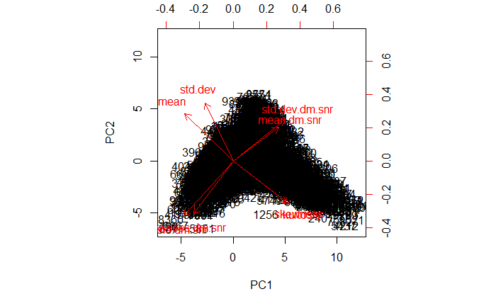

```r
biplot(pca, scale=0)
```

```r
summary(pca)
```

```
Importance of components:
                        PC1   PC2   PC3    PC4    PC5    PC6     PC7     PC8
Standard deviation     2.04 1.458 0.898 0.6743 0.5111 0.3984 0.14343 0.12396
Proportion of Variance 0.52 0.266 0.101 0.0568 0.0327 0.0198 0.00257 0.00192
Cumulative Proportion  0.52 0.785 0.886 0.9430 0.9757 0.9955 0.99808 1.00000
```

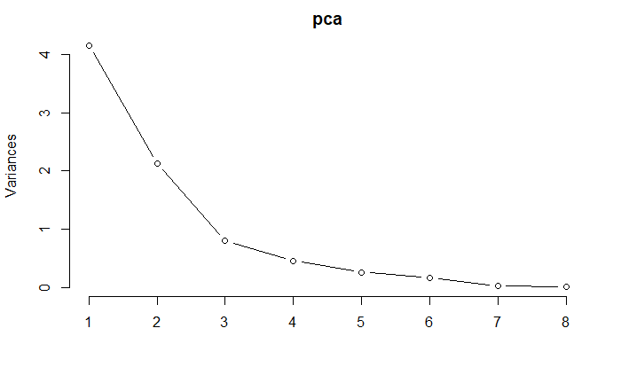

```r
screeplot(pca,type = 'l')
```

Cumulative variance explained by the first two principle components is 78.5%.

### Question 2.3-A-ii

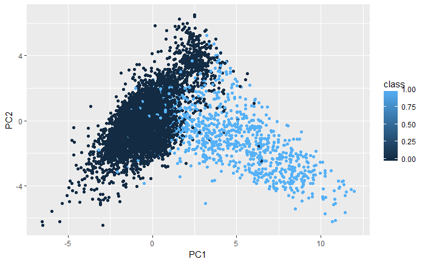

```r
ggplot(data = HTRU_2data, mapping = aes(x = pca$x[,1], y = pca$x[,2], colour = class)) +
geom_point() + labs(x="PC1",y="PC2",colour="class")
```

### Question 2.3-A-iii

From the biplot and ggplot we can infer that there is a clear disction between the two classes.Most of the class 0 data points lie on the range [2.5 to -7].The data points with class 1 lie only on the positive side of PC1. The data points with class label 1 have higher skewness and kurtosis.Excess skewness and kurtosis of the DM-SNR curve show for data points with class label 0. We can also observe that we have less number of observations of class 1 than class 0 and data points of class 0 are more dense than class 1. The data points which lie on the negative side of PC2 tend to have higher skewness and kurtosis and data points on the positive side of PC2 tend to have higher mean and standard deviation.

### Question 2.3-B-i

Scaling the data before performing kmeans on the HTRU_2 dataset.Scaling is done because there are deviations between the column values.

```r
sc <- scale(HTRU_2data[,1:8])
kmeans_HTRU_2 <- kmeans(sc,centers = 2)
```

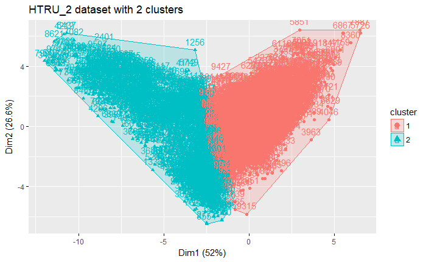

```r
fviz_cluster(kmeans_HTRU_2, data=sc, main="HTRU_2 dataset with 2 clusters")
```

### Question 2.3-B-ii

The shapes of the graphs for kmeans and PCA are similar but the data points are inverted in the PCA model because we performed a pca rotation operation to interpret the results in 2 dimensions using a biplot.Kmeans clustering model did well by having most of the class 0 datas in cluster 1 and class 1 data points in cluster2.

### Question 2.3-B-iii

```r
cat("Number of observations in each cluster are: ",kmeans_HTRU_2$size)
```

```
Number of observations in each cluster are:  8847 1153
```

### Question 2.3-B-iv

```r
table(HTRU_2data[,9])
```

```
   0    1
9041  959
```

HTRU_2 dataset has 9041 observations of class 0 and 959 observations of class 1.

### Question 2.3-B-v

From the observed results above cluster 1 corresponds to majority cluster with class label 0 and cluster 2 corresponds to minority class with class label 1.

### Question 2.3-B-vi

```r
names(kmeans_HTRU_2)
```

```
[1] "cluster"      "centers"      "totss"        "withinss"     "tot.withinss" "betweenss"
[7] "size"         "iter"         "ifault"
```

```r
km_1 <- which(kmeans_HTRU_2$cluster==1)
```

```r
new_class_HTRU_2 <- HTRU_2data[km_1,]
head(new_class_HTRU_2)
```

|  | mean | std.dev | kurtosis | skewness | mean.dm.snr | std.dev.dm.snr | kurtosis.dm.snr | skewness.dm.snr | class |
| --- | --- | --- | --- | --- | --- | --- | --- | --- | --- |
| 2 | 121.76 | 44.749 | 0.2318190 | 0.184609 | 3.7609 | 22.869 | 6.7186 | 47.953 | 0 |
| 4 | 130.07 | 51.387 | -0.1601283 | -0.209469 | 2.0251 | 13.170 | 10.0161 | 138.329 | 0 |
| 5 | 111.12 | 35.635 | 0.2376726 | 1.679231 | 3.6881 | 18.683 | 6.6634 | 54.091 | 0 |
| 6 | 138.46 | 52.775 | -0.0090906 | -0.551845 | 2.2207 | 13.204 | 9.9537 | 139.467 | 0 |
| 7 | 135.73 | 48.496 | -0.0178888 | -0.115854 | 3.3370 | 20.431 | 9.0557 | 93.278 | 0 |
| 8 | 137.25 | 48.866 | -0.1651200 | -0.092291 | 3.8520 | 19.553 | 6.5998 | 52.034 | 0 |

```r
cat("Number of observations in large cluster that belong to class 1 are: ",sum(new_class_HTRU_2$class == "1"))
```

```
Number of observations in large cluster that belong to class 1 are:  223
```

```r
cat("Number of observations in large cluster that belong to class 0 are: ",sum(new_class_HTRU_2$class == "0"))
```

```
Number of observations in large cluster that belong to class 0 are:  8624
```

### Question 2.3-B-vii

From the observed results the large cluster represents data points of class label 0.

### Question 2.3-B-viii

```r
kmeans_HTRU_2
```

```
K-means clustering with 2 clusters of sizes 8847, 1153

Cluster means:
      mean   std.dev kurtosis skewness mean.dm.snr std.dev.dm.snr kurtosis.dm.snr skewness.dm.snr
1  0.19109  0.076265 -0.23776 -0.22095    -0.28709        -0.2884         0.21123         0.12662
2 -1.46627 -0.585183  1.82437  1.69536     2.20281         2.2129        -1.62075        -0.97154

Clustering vector:
   [1] 2 1 2 1 1 1 1 1 1 1 1 1 1 2 1 1 1 1 1 1 1 1 2 1 1 1 1 1 2 1 1 1 1 2 1 1 1 1 1 1 1 1 1 1 1 1
  [47] 1 1 1 1 1 1 1 1 1 1 1 1 1 1 1 1 2 1 1 1 2 1 1 1 2 2 2 1 2 2 1 1 1 1 1 1 2 1 1 2 1 1 1 2 1 1
  [93] 1 2 2 1 1 1 2 2 1 1 2 1 1 1 1 1 1 1 1 1 1 1 1 1 1 1 1 2 1 2 1 1 1 1 1 1 1 1 1 1 1 1 1 1 1 2
 [139] 1 2 1 1 1 1 1 2 1 1 1 1 1 1 1 1 1 1 1 2 2 1 1 1 2 1 1 1 1 2 2 1 1 1 1 1 1 1 1 1 1 1 1 1 1 1
 [185] 1 1 1 1 1 1 1 1 1 1 1 1 1 1 1 1 1 1 2 1 2 1 1 1 1 1 1 2 1 1 1 1 1 2 1 1 1 1 1 1 1 1 1 1 1 1
 [231] 1 1 1 1 1 1 1 1 1 1 1 1 1 1 1 1 1 1 1 1 1 1 1 1 1 1 1 2 1 1 1 1 1 1 1 2 1 1 1 2 1 1 1 1 1 1
 [277] 1 1 1 1 1 2 1 1 1 1 1 1 1 1 1 1 1 1 2 1 1 1 1 1 1 1 1 1 1 1 1 1 1 1 1 1 1 2 1 1 1 1 1 1 1 1
 [323] 2 2 1 1 1 1 1 1 1 1 2 1 2 1 1 1 1 1 2 1 1 1 1 1 1 1 1 2 1 1 2 1 1 1 1 1 1 1 2 1 1 1 1 1 1 1
 [369] 1 1 1 1 1 1 1 1 1 1 1 1 1 2 1 2 1 1 2 1 2 1 1 1 1 1 1 1 1 1 2 1 1 1 1 1 1 1 1 1 1 1 1 1 1 1
 [415] 1 1 1 1 1 1 1 1 1 1 1 1 1 1 1 1 1 1 1 1 1 2 1 2 1 1 2 2 1 1 1 1 1 1 1 1 1 1 1 1 2 1 1 1 1 2
 [461] 2 2 1 1 1 1 1 1 1 2 1 1 2 1 2 1 1 1 1 1 1 1 1 1 1 1 2 1 1 1 1 1 1 1 1 1 1 1 1 1 1 2 1 1 1 1
 [507] 1 1 1 2 2 1 1 1 1 1 1 1 1 1 2 1 1 1 1 1 1 1 1 1 1 1 1 1 1 1 2 1 1 1 1 1 1 1 1 1 1 1 1 1 2 2
 [553] 1 1 1 1 2 1 1 1 1 1 1 1 1 1 1 1 1 1 1 1 1 1 1 1 2 1 1 1 1 1 1 2 1 1 1 1 1 1 1 1 1 1 1 1 1 1
 [599] 1 1 1 1 1 2 1 1 1 1 1 1 1 1 1 1 1 2 1 1 1 1 1 1 1 1 2 1 2 1 1 1 1 1 1 1 1 1 1 1 1 1 1 1 1 1
 [645] 2 1 1 2 1 1 1 1 2 1 1 1 1 1 2 1 1 1 1 1 1 1 1 1 1 1 1 1 1 1 1 1 1 1 1 1 2 1 1 1 1 1 1 1 1 1
 [691] 1 2 1 1 1 2 1 2 2 2 1 1 1 1 1 1 1 1 1 1 1 1 1 1 1 2 1 1 1 1 1 1 1 1 1 1 1 1 1 1 1 1 2 1 1 2
 [737] 1 1 1 1 1 1 1 1 1 1 1 1 1 1 1 1 1 1 1 1 1 1 1 2 1 1 2 1 1 2 1 2 1 1 1 1 1 1 1 1 1 1 1 1 1 1
 [783] 1 2 1 1 2 1 1 1 1 1 2 1 1 1 1 1 1 1 2 1 1 1 1 1 1 1 1 1 1 1 1 1 2 1 2 1 1 1 1 1 1 1 1 1 1 1
 [829] 2 1 1 1 1 1 1 1 1 1 1 2 1 1 1 2 1 1 1 1 1 2 2 1 1 1 1 1 1 2 1 1 2 1 1 1 1 2 1 1 1 2 1 1 1 1
 [875] 1 1 1 1 1 1 1 1 1 1 1 1 2 1 1 1 1 1 1 1 1 1 1 1 1 1 1 1 1 1 1 1 2 1 1 1 1 1 1 1 1 1 1 2 1 1
 [921] 1 1 1 1 1 1 2 1 1 2 1 1 1 1 1 1 1 1 1 2 1 1 1 1 1 1 2 1 1 1 1 1 1 1 1 1 1 2 1 1 1 2 1 2 1 1
 [967] 2 1 1 1 1 1 2 2 1 1 1 1 1 2 1 1 1 1 1 1 1 1 2 1 1 1 1 1 2 1 1 1 1 1
 [ reached getOption("max.print") -- omitted 9000 entries ]

Within cluster sum of squares by cluster:
[1] 30015 21285
 (between_SS / total_SS =  35.9 %)

Available components:

[1] "cluster"      "centers"      "totss"        "withinss"     "tot.withinss" "betweenss"
[7] "size"         "iter"         "ifault"
```

Kmeans clustering model explains 35.9% of the variance.

### Question 2.3-B-ix

```r
stats_kmc <- cluster.stats(dist(sc),kmeans_HTRU_2$cluster)
names(stats_kmc)
```

```
 [1] "n"                  "cluster.number"     "cluster.size"       "min.cluster.size"
 [5] "noisen"             "diameter"           "average.distance"   "median.distance"
 [9] "separation"         "average.toother"    "separation.matrix"  "ave.between.matrix"
[13] "average.between"    "average.within"     "n.between"          "n.within"
[17] "max.diameter"       "min.separation"     "within.cluster.ss"  "clus.avg.silwidths"
[21] "avg.silwidth"       "g2"                 "g3"                 "pearsongamma"
[25] "dunn"               "dunn2"              "entropy"            "wb.ratio"
[29] "ch"                 "cwidegap"           "widestgap"          "sindex"
[33] "corrected.rand"     "vi"
```

```r
cat("Average Silhouette width for both clusters is :",stats_kmc$avg.silwidth)
```

```
Average Silhouette width for both clusters is : 0.60068
```

### Question 2.3-B-x

```r
cat("Per cluster Silhouette width is :",stats_kmc$clus.avg.silwidths)
```

```
Per cluster Silhouette width is : 0.6592 0.15164
```

Based on the per cluster Silhouette width Cluster 1 is better since its value is close to 1.

### Question 2.3-C-i

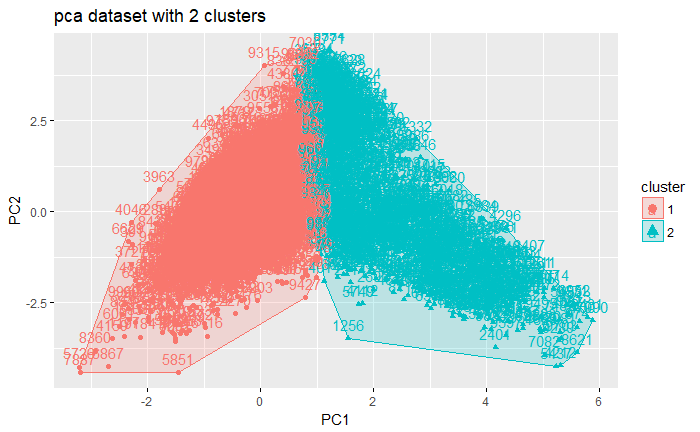

```r
pca_kms <- kmeans(pca$x[,1:2],centers = 2)
fviz_cluster(pca_kms, data=pca$x[,1:2], main="pca dataset with 2 clusters")
```

The shapes of the plots in a(ii) and b(i) are similar but the plot in b(i) is ploted in different axis since other two plots are plotted using two axis which has higher variance.

### Question 2.3-C-ii

```r
stats_pca_ss <- cluster.stats(dist(pca$x[,1:2]),pca_kms$cluster)
names(stats_pca_ss)
```

```
 [1] "n"                  "cluster.number"     "cluster.size"       "min.cluster.size"
 [5] "noisen"             "diameter"           "average.distance"   "median.distance"
 [9] "separation"         "average.toother"    "separation.matrix"  "ave.between.matrix"
[13] "average.between"    "average.within"     "n.between"          "n.within"
[17] "max.diameter"       "min.separation"     "within.cluster.ss"  "clus.avg.silwidths"
[21] "avg.silwidth"       "g2"                 "g3"                 "pearsongamma"
[25] "dunn"               "dunn2"              "entropy"            "wb.ratio"
[29] "ch"                 "cwidegap"           "widestgap"          "sindex"
[33] "corrected.rand"     "vi"
```

```r
cat("Average Silhouette width for both clusters is :",stats_pca_ss$avg.silwidth)
```

```
Average Silhouette width for both clusters is : 0.64943
```

### Question 2.3-C-iii

```r
cat("Per cluster Silhouette width is :",stats_pca_ss$clus.avg.silwidths)
```

```
Per cluster Silhouette width is : 0.70399 0.22913
```

Based on the per cluster Silhouette width Cluster 1 is better since its value is close to 1.

### Question 2.3-C-iv

performing kmeans clustering with PCA1 and PCA2 vectors obtained higher Average Silhoutte width (0.649) and per cluster silhoutte width (0.704,0.229) than clustering the HTRU_2 dataset with all the attributes. The Average silhouette width obtained using HTRU_2 dataset in part b is (0.6001) and the per cluster silhouette width is (0.659,0.152) which is lower than the vaules obtained in part c using PCA vectors.Therefore,clustering with PCA vectors in part c obtained better results of silhouette with than the results obtained in part b.